# February 18, 2013 Class Notes

### Back to RMarkdown

Several people had problems compiling their documents. These were caused by ill-formed commands earlier in the document.

Use the “Chunks” menu to run individual chunks by copying them to your console.

Write up a short document about partitioning variance and post it to Moodle.

### Notation

In the `lm()` program (and `mm()` and `glm()` programs), we write the response variable to the left of the `~` and the model terms, separated by the `+` notation, on the right side. Don't confuse `+` with mathematical addition. It really is just a separator for the various terms we are going to be including in the linear combination that will constitute the model.

- The `1` means “intercept”. As it happens, the software will automatically include the intercept even if you don't say `1`. If you want to exclude the intercept, you use a special notation: `-1`.

Example of simple models with and without the intercept term.

```r
lm(height ~ 1 + father, data = Galton)
```

```
##
## Call:
## lm(formula = height ~ 1 + father, data = Galton)
##
## Coefficients:
## (Intercept)       father
##      39.110        0.399
```

```r
lm(height ~ father, data = Galton)  # same thing as previous
```

```
##
## Call:
## lm(formula = height ~ father, data = Galton)
##
## Coefficients:
## (Intercept)       father
##      39.110        0.399
```

```r
lm(height ~ father - 1, data = Galton)  # leave out intercept
```

```
##
## Call:
## lm(formula = height ~ father - 1, data = Galton)
##
## Coefficients:
## father
##  0.964
```

- The name of the variable, e.g. `father` means that variable as a main effect.
- An interaction term is introduced with a `:` between variable names.

```r
lm(height ~ father + mother + father:mother, data = Galton)
```

```
##
## Call:
## lm(formula = height ~ father + mother + father:mother, data = Galton)
##
## Coefficients:
##   (Intercept)         father         mother  father:mother
##      132.3478        -1.2060        -1.4294         0.0247
```

- Since the polynomial modeling heuristic includes main effects by default, there is a special notation to signal that we want both the main effects and the interaction:

```r
lm(height ~ father * mother, data = Galton)
```

```
##
## Call:
## lm(formula = height ~ father * mother, data = Galton)
##
## Coefficients:
##   (Intercept)         father         mother  father:mother
##      132.3478        -1.2060        -1.4294         0.0247
```

- Transformation terms: apply the function to the variable. Example:

```r
lm(height ~ cos(father), data = Galton)  # silly model!
```

```
##
## Call:
## lm(formula = height ~ cos(father), data = Galton)
##
## Coefficients:
## (Intercept)  cos(father)
##     66.7618      -0.0094
```

```r
swim = fetchData("swim100m.csv")
```

```
## Retrieving from http://www.mosaic-web.org/go/datasets/swim100m.csv
```

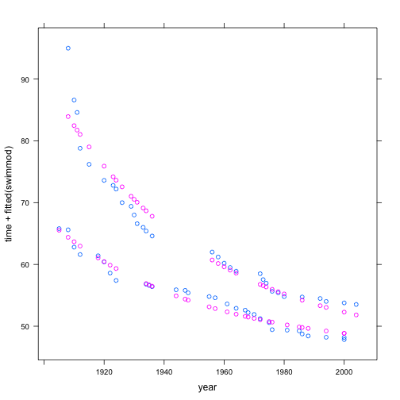

```r
swimmod = lm(time ~ sex * exp(-year/50), data = swim)
xyplot(time + fitted(swimmod) ~ year, data = swim)
```

- Quadratic terms are fairly common, and so there is a nice way to specify that you want both the main effect and higher-order polynomial terms:

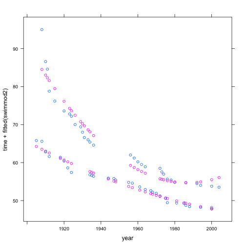

```r
swimmod2 = lm(time ~ sex * poly(year, 2), data = swim)
xyplot(time + fitted(swimmod2) ~ year, data = swim)
```

N.B. For instructors … You may be tempted to write polynomial terms directly, for instance

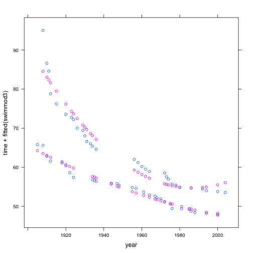

```r
swimmod3 = lm(time ~ sex * (year + I(year^2)), data = swim)
xyplot(time + fitted(swimmod3) ~ year, data = swim)
```

Note the use of `I()` to instruct R to treat arithmetical symbols in the numerical way. Also, note that `poly()` cleverly does a shift into orthogonal polynomials to preserve numerical stability. As such, the specific coefficients in `swimmod2` and `swimmod3` will be different, even though the model formulas amount to the same thing.

```r
swimmod2
```

```
##
## Call:
## lm(formula = time ~ sex * poly(year, 2), data = swim)
##
## Coefficients:
##         (Intercept)                 sexM       poly(year, 2)1
##               64.57                -9.64               -76.13
##      poly(year, 2)2  sexM:poly(year, 2)1  sexM:poly(year, 2)2
##               27.23                36.31               -22.49
```

```r
swimmod3
```

```
##
## Call:
## lm(formula = time ~ sex * (year + I(year^2)), data = swim)
##
## Coefficients:
##    (Intercept)            sexM            year       I(year^2)
##       1.90e+04       -1.54e+04       -1.90e+01        4.79e-03
##      sexM:year  sexM:I(year^2)
##       1.56e+01       -3.96e-03
```

In order to deal with the possible double meaning of symbols like `+`, you can use `I()` to signal to R to treat the mathematical operations literally.

## Comparing `mm` and `lm`

Model wage by `sex`, `sector` and `exper`

### `mm` approach — divide up into groups

```r
mod1 = mm(wage ~ sex + sector + cut(exper, breaks = c(0, 5, 10, 20, 40)), data = CPS85)
head(confint(mod1))
```

```
##              group   2.5 % 97.5 %
## 1 F.clerical.(0,5]  1.5790  8.078
## 2 M.clerical.(0,5]  4.0547 10.554
## 3    F.const.(0,5]     NaN    NaN
## 4    M.const.(0,5]  2.8324 20.028
## 5    F.manag.(0,5] 10.6770 18.367
## 6    M.manag.(0,5] -0.5344 11.624
```

Problem: many, many groups, so not much data in each.

### `lm` approach — select terms

```r
mod2 = lm(wage ~ sex + sector + exper, data = CPS85)
confint(mod2)
```

```
##                  2.5 %  97.5 %
## (Intercept)    4.85391  7.0288
## sexM           1.28076  3.0176
## sectorconst   -2.13439  2.4662
## sectormanag    2.84352  5.9354
## sectormanuf   -1.90184  1.0235
## sectorother   -1.82014  1.2482
## sectorprof     2.74612  5.3096
## sectorsales   -2.33520  1.1299
## sectorservice -2.79908 -0.1037
## exper          0.02609  0.0895
```

Now the question is how to interpret these confidence intervals. Do we compare them to one another or to zero?

## Introducing \( R^2 \) Briefly

Since we're trying to account for variation in the response variable, it's helpful to have a way to quantify how much variation we have accounted for. The quantity called “R-squared” — \( R^2 \), officially “the coefficient of determination” although hardly anyone uses that name — is a standard way to do this. Briefly, \( R^2 \) is the fraction of variance in the response variable that is “captured” by the model. It is always between 0 (didn't capture any) and 1 (got it all!).

### Activity

Visual choice of model terms

Instructions are [given here](http://dl.dropbox.com/u/5098197/Exercises/HTML/ISM-Selecting-Model-Terms/ISM-Selecting-Model-Terms-A.html?access=ISM3) (These have to be reformatted as a handout and as an instructor's guide.)

The only substantive differences is in the way the software is loaded:

```r
fetchData("mLM.R")
```

```
## Retrieving from http://www.mosaic-web.org/go/datasets/mLM.R
```

```
## [1] TRUE
```

The program itself is called `mLM()` (not `lm.select.terms()`)

## Model Formulas and Coefficients

Fit some models and work students through the calculations. The `makeFun()` function can help in this.

A suggested style for a calculation:

```r
mod = lm(wage ~ sex + age, data = CPS85)
coef(mod)
```

```
## (Intercept)        sexM         age
##     4.65425     2.27469     0.08522
```

What is the wage for a female of age 40? A male of age 30? Work through the arithmetic “by hand”.

```r
4.65 + 0 * 2.274 + 40 * 0.0852  # for the 40-year old female
```

```
## [1] 8.058
```

```r
4.65 + 1 * 2.274 + 30 * 0.0852  # for the 30-year old male
```

```
## [1] 9.48
```

You can also turn the model information into a mathematical function:

```r
f = makeFun(mod)
f(sex = "F", age = 40)
```

```
##     1
## 8.063
```

```r
f(sex = "M", age = 30)
```

```
##     1
## 9.485
```

Other settings:

- Natural gas usage by average temperature in `utilities.csv`
- … more …

## Form Groups for Car Project

Outline the [used car project](https://dl.dropbox.com/u/5098197/Exercises/HTML/SM2-Chapter-7-Problems/SM2-Chapter-7-Problems-A.html?access=ISMf12#723) and show some data from http://www.cars.com. Perhaps MINI Coopers.

Get students to form groups right now, oriented around different kinds of cars. They should make a Google Spreadsheet and share it with all the other members of their group.

## Units of coefficients

- Quick review of the arithmetic of units and dimensions.
- Simple examples:
  - foot width as a function of foot length and sex (explain why length is a sensible explanatory variable and width is a sensible response when trying to model whether girls' feet are narrower than boys': the way shoes are sized by length.)
  - child's height as a function of the father's height. Then introduce an interaction between father and mother to get at the units.

## Example of an Interaction

The story is pretty straightforward. Your job is to see why this corresponds to an interaction term:

Newspaper article: [a study of “hidden” ovulation](http://www.nytimes.com/2011/02/22/science/22tier.html?_r=1&hp) and whether it's really hidden. Note the interaction between ovulation phase and romantic attachment. : “Previous research had shown that a woman at the fertile stage of her menstrual cycle seems more attractive, and that same effect was observed here — but only when this woman was rated by a man who wasn’t already involved with someone else. The other guys, the ones in romantic relationships, rated her as significantly less attractive when she was at the peak stage of fertility, presumably because at some level they sensed she then posed the greatest threat to their long-term relationships.